# Sistemas Operacionais

Thiago Pires

# Fundamentos de Sistemas Operacionais

> A função do sistema operacional é fornecer aos programas do usuário um modelo do computador melhor, mais simples e mais limpo, assim como lidar com o gerenciamento de todos os recursos mencionados. *A maioria dos computadores tem dois modos de operação: modo núcleo e modo usuário.*

## Fundamentos de Sistemas Operacionais

O sistema operacional opera em modo núcleo (também chamado modo supervisor). Nesse modo, ele tem acesso completo a todo o hardware e *pode executar qualquer instrução* *que a máquina for capaz de executar.*

Observe, na figura a seguir, uma visão geral simplificada dos principais componentes:

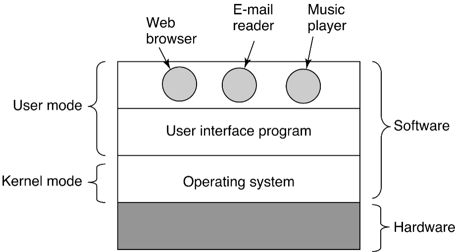

## Fundamentos de Sistemas Operacionais

O resto do software opera em modo usuário, no qual apenas um subconjunto das instruções da máquina está disponível.

A diferença entre os modos exerce papel crucial na maneira como os sistemas operacionais funcionam.

Os sistemas operacionais são enormes, complexos e têm vida longa. O código-fonte do coração de um sistema operacional como Linux ou Windows tem cerca de cinco milhões de linhas.

## O que é um sistema operacional?

> *Os sistemas operacionais realizam duas funções essencialmente não relacionadas: (1) fornecer a programadores de aplicativos (e programas aplicativos, claro) um conjunto de recursos abstratos limpo em vez de recursos confusos de hardware, e (2) gerenciar esses recursos de hardware*

## O que é um sistema operacional?

> *Sistemas operacionais transformam o feio em belo, como mostrado na figura:*

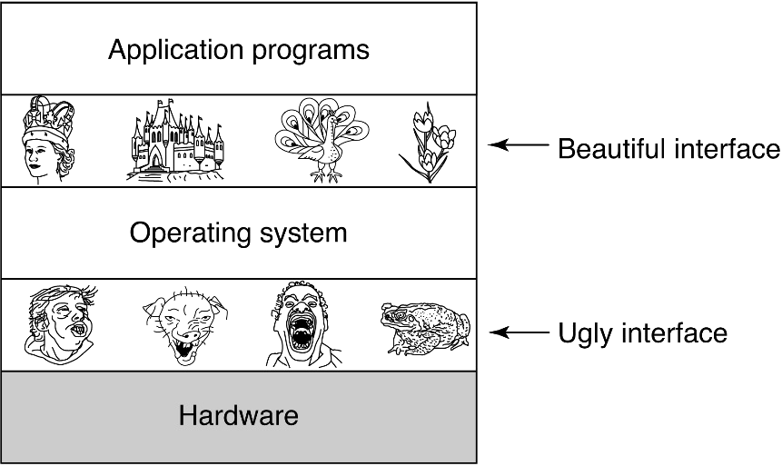

Usando essa abstração, os programas podem criar, escrever, ler arquivos, sem ter que lidar com detalhes complexos de como o hardware funciona

## O que é um sistema operacional?

> *O conceito de um sistema operacional como fundamentalmente fornecendo abstrações para programas aplicativos é uma visão top-down (abstração de cima para baixo). Uma visão alternativa, bottom-up (abstração de baixo para cima), sustenta que o sistema operacional está ali para gerenciar todas as partes de um sistema complexo.*

## O que é um sistema operacional?

O gerenciamento de recursos inclui a multiplexação (compartilhamento) de recursos de duas maneiras diferentes: no tempo e no espaço.

- Quando um recurso é multiplexado no tempo, diferentes programas ou usuários se revezam usando-o.
- O outro tipo é a multiplexação de espaço. Em vez de os clientes se revezarem, cada um tem direito a uma parte do recurso.

## O que é um sistema operacional?

1. *Quando múltiplas saídas de impressão estão na fila para serem impressas em uma única impressora, uma decisão tem de ser tomada sobre qual deve ser impressa em seguida.*

Multiplexado no tempo

2. *Em vez de os clientes se revezarem, cada um tem direito a uma parte do recurso. Por exemplo, a memória principal é normalmente dividida entre vários programas sendo executados, de modo que cada um pode ser residente ao mesmo tempo (por exemplo, a fim de se revezar usando a CPU).*

Multiplexado no espaço

## Revisão sobre hardware de computadores

> *Um sistema operacional está intimamente ligado ao hardware do computador no qual ele é executado*

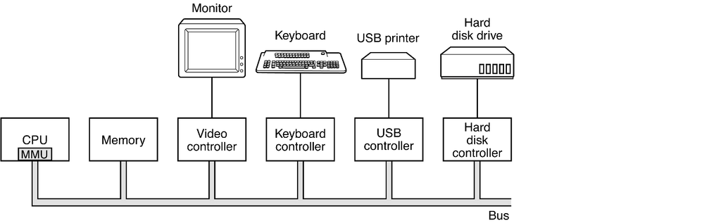

A CPU, memória e dispositivos de E/S estão todos conectados por um sistema de barramento (*bus*) e comunicam-se uns com os outros sobre ele.

## Revisão sobre hardware de computadores

### Processadores

> *O “cérebro” do computador é a CPU. O ciclo básico de toda CPU é buscar a primeira instrução da memória, decodificá-la para determinar o seu tipo e operandos, executá-la.*

Cada CPU tem um conjunto específico de instruções que ela consegue executar. *Desse modo, um processador x86 não pode executar programas ARM.*

As CPUs têm alguns registradores internos para armazenamento de variáveis e resultados temporários.

Os resgistradores são importantes por causa da multiplexação de tempo da CPU.

## Revisão sobre hardware de computadores

### Memória

> *É o segundo principal componente em qualquer computador, o qual deve ser rápido ao extremo (mais rápida do que executar uma instrução, de maneira que a CPU não seja atrasada pela memória).*

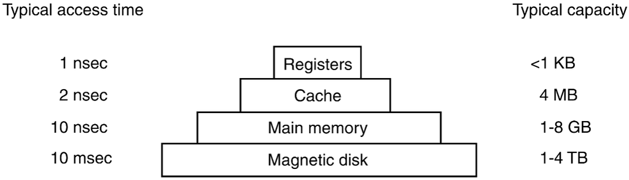

## Memória

A camada superior consiste em registradores internos à CPU. Eles são feitos do mesmo material que a CPU e são, desse modo, tão rápidos quanto ela

Memória cache é uma parte da CPU. Atua como memória temporária para que seja recuperado rapidamente os dados, sem a necessidade de uma busca direta na memória principal

Mémoria principal tem por finalidade o armazenamento de instruções e dados de programas que serão ou estão sendo executados pela CPU.

Discos magnéticos são um tipo de memória não volátil de grande capacidade de armazenamento, usada para guardar informações (instruções e dados de programas) que não serão imediatamente usadas pela CPU.

## Exemplo de utilização de cache

DuckDB tem uma forma de consulta (*vectorized or just-in-time query execution engines*) que são processadas em lotes de dados que consistem em coleções de vetores, cada um contendo uma quantidade fixa de valores das colunas.

O resultado é um uso eficiente das operações no cache, mantendo os dados nas consultas tanto quanto possível no cache L1 e L2 muito rápido.

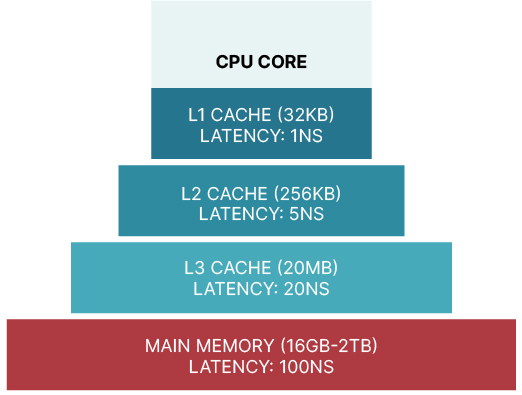

Fonte: blog.min.io/duckdb-and-minio-for-a-modern-data-stack/

## O zoológico dos sistemas operacionais

- Sistemas operacionais de computadores de grande porte, de alto desempenho e alta disponibilidade (*mainframes*)
- Sistemas operacionais de servidores
- Sistemas operacionais de computadores pessoais
- Sistemas operacionais de computadores portáteis
- Sistemas operacionais embarcados
- Sistemas operacionais de tempo real

## Conceitos de sistemas operacionais

- **Processos:** um processo é basicamente um programa em execução e associado a cada processo está um espaço de endereçamento, uma lista de posições de mémoria que vai de 0 a algum máximo, onde o processo pode ler e escrever.
- **Espaços de endereçamento:** diz respeito ao gerenciamento e à proteção da memória principal do computador, quando se tem multiplos processos sendo executados.
- **Arquivos:** um sistema de arquivos é uma estrutura usada por um sistema operacional para organizar e gerenciar arquivos em um dispositivo de armazenamento. Chamadas do sistemas são necessárias para criar, remover, ler escrever arquivos. Existe o conceito de diretório como uma maneira de agrupar os arquivos

## Conceitos de sistemas operacionais

- **Entrada/Saída:** o sistema operacional tem um subsistema de E/S para gerenciamento dos dispositivos.
- **Proteção:** o sistema operacional gerencia a segurança do sistema de maneira que os arquivos, por exemplo, sejam acessíveis somente por usuários autorizados.
- **Interpretador de comandos (shell):** é a principal interface entre um usuário e o sistema operacional.

## Conceitos de sistemas operacionais

> *Memória virtual: A memória virtual proporciona a capacidade de executar programas maiores do que a memória física da máquina, rapidamente movendo pedaços entre a memória RAM e o disco.*

Quando se instala o linux é possível definir o tamanho da partição do disco que será utilizado pela memória virtual (swap).

## Chamadas de sistema

github.com/unasp-aulas/sistemas-operacionais